# Bioestadística, Zootecnia

Departamento de Estadística, Sede Bogotá

## Contenido

### Parte I: Bloques Completos Aleatorizados

- Motivación: por qué bloquear.
- El modelo del RCBD.
- Descomposición de la suma de cuadrados.
- Tabla ANOVA y ejemplo: cerdos en el altiplano.
- Verificación del modelo y residuos.
- Eficiencia relativa del bloqueo.
- Observación faltante y modelo de regresión.

### Parte II: Cuadrado Latino

- Motivación: dos fuentes de variación extraña.
- Estructura y aleatorización.
- Modelo estadístico.
- Ejemplo: dietas para aves en el Tolima.
- Tabla ANOVA de cuatro fuentes.

### Parte III: Cuadrado Greco-Latino

- Motivación: tres fuentes de variación extraña.
- Estructura y modelo.
- Condiciones de uso y limitaciones.
- Ejemplo conceptual: suplementos.

### Parte IV: Bloques Incompletos Balanceados

- Motivación: capacidad limitada de bloque.
- Análisis estadístico del BIBD.
- Estimación por mínimos cuadrados.
- Recuperación de información interbloque.
- Ejemplo: dietas para ganado.
- Taller en clase.

Diseños con Restricciones de Aleatorización

En los experimentos pecuarios reales, casi nunca todo el material experimental es homogéneo. ¿Cómo controlamos la variabilidad que no nos interesa, sin perder la capacidad de comparar tratamientos?

## Motivación: por qué bloquear

En el Diseño Completamente Aleatorizado (DCA) se asume que todas las unidades experimentales son homogéneas. Sin embargo, en campo esto rara vez ocurre: las granjas difieren en altitud, tipo de dieta, manejo previo o disponibilidad de agua.

El problema

Si la variabilidad entre granjas se mezcla con el error experimental, el $CM_E$ se infla y se reduce la capacidad de detectar diferencias reales entre tratamientos.

La solución: bloquear

Se agrupan las unidades experimentales en **bloques** homogéneos (ej. granjas), y se aplican todos los tratamientos dentro de cada bloque, aislando esa fuente de variación.

Ejemplo: comparar 4 dietas para cerdos en 5 granjas distintas del altiplano cundiboyacense. La granja no es de interés directo, pero afecta el productividad; bloquear por granja permite “restarle” esa variabilidad al error experimental.

## El Diseño de Bloques Completos Aleatorizados (RCBD)

En un RCBD, cada **bloque** contiene exactamente una réplica de **todos** los tratamientos (de ahí “completo”), y dentro de cada bloque el orden de los tratamientos se asigna al azar (de ahí “aleatorizado”).

Modelo del RCBD

$$y_{ij} = \mu + \tau_i + \beta_j + \varepsilon_{ij}
\qquad
\begin{cases}
i=1,\ldots,a \text{ (tratamientos)} \\
j=1,\ldots,b \text{ (bloques)}
\end{cases}$$

- $\mu$: media general. $\tau_i$: efecto del tratamiento $i$. $\beta_j$: efecto del bloque $j$.
- $\varepsilon_{ij}\sim N(0,\sigma^2)$ independientes.
- Restricciones: $\sum_i \tau_i = 0$, $\sum_j \beta_j = 0$.
- A diferencia del DCA, ahora el modelo separa explícitamente la variabilidad debida al bloque.

## Hipótesis y supuestos del RCBD

El interés principal del RCBD recae en el efecto de tratamiento; el bloque se incluye para controlar variabilidad, no para realizar inferencia sobre él.

**Hipótesis de interés**
$$H_0:\tau_1=\cdots=\tau_a=0$$
$$H_1:\text{algún } \tau_i\neq0$$

**Supuestos del modelo**  
Normalidad, homogeneidad de varianza, independencia y aditividad (sin interacción tratamiento-bloque).

La aleatorización se restringe: dentro de cada bloque, los tratamientos se asignan al azar a las unidades experimentales, pero el bloque mismo no se aleatoriza.

## Ejemplo pecuario: dietas para cerdos en el altiplano

Un profesional en zootecnia del ICA evalúa el productividad (kg/animal) de 4 dietas para cerdos: **Dieta B**, **Dieta A**, **ICA Única** y **Dieta C**, asignadas en 5 granjas de Cundinamarca y Boyacá (Subachoque, Toca, Villapinzón, Tausa, Zipaquirá), cada una usada como bloque.

| Granja (bloque) | Dieta B | Dieta A | ICA Única | Dieta C |
| --- | --- | --- | --- | --- |
| Subachoque | 27.6 | 31.9 | 32.8 | 25.9 |
| Toca | 30.2 | 32.7 | 32.6 | 26.6 |
| Villapinzón | 26.1 | 29.3 | 33.0 | 25.3 |
| Tausa | 31.3 | 34.6 | 33.2 | 28.1 |
| Zipaquirá | 25.9 | 27.6 | 29.3 | 21.0 |

Cada granja recibe las 4 dietas en orden aleatorio: hay $a=4$ tratamientos y $b=5$ bloques, con $N=20$ observaciones en total.

## Medias por tratamiento y por bloque

| Dieta | $\bar y_{i.}$ (kg/animal) |
| --- | --- |
| Dieta B | 28.22 |
| Dieta A | 31.22 |
| ICA Única | 32.18 |
| Dieta C | 25.38 |

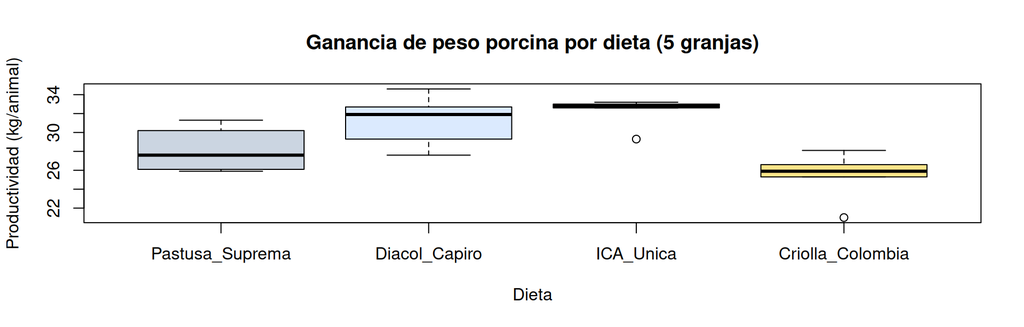

La media general es $\bar y_{..}=29.25$ kg/animal. Las granjas también difieren: Tausa promedia 31.80 kg/animal y Zipaquirá solo 25.95 kg/animal, evidenciando la necesidad de bloquear.

## Descomposición de la suma de cuadrados en el RCBD

La variabilidad total ahora se descompone en **tres** componentes: tratamiento, bloque y error.

Identidad fundamental del RCBD

$$\underbrace{\sum_{i}\sum_{j}(y_{ij}-\bar y_{..})^2}_{SC_T}
=
\underbrace{b\sum_{i} (\bar y_{i.}-\bar y_{..})^2}_{SC_{Trat}}
+
\underbrace{a\sum_{j} (\bar y_{.j}-\bar y_{..})^2}_{SC_{Bloq}}
+
\underbrace{\sum_{i}\sum_{j}(y_{ij}-\bar y_{i.}-\bar y_{.j}+\bar y_{..})^2}_{SC_E}$$

$SC_{Trat}$: variabilidad entre dietas.

$SC_{Bloq}$: variabilidad entre granjas.

$SC_E$: variabilidad residual no explicada.

## Cálculo de las sumas de cuadrados: ejemplo de los cerdos

**Paso 1. Suma de cuadrados total:**
$$SC_T=\sum_i\sum_j(y_{ij}-29.25)^2=235.97$$

**Paso 2. Suma de cuadrados de tratamiento y bloque:**
$$SC_{Trat}=5\sum_i (\bar y_{i.}-29.25)^2=142.52$$
$$SC_{Bloq}=4\sum_j (\bar y_{.j}-29.25)^2=79.16$$

**Paso 3. Suma de cuadrados del error:**
$$SC_E=SC_T-SC_{Trat}-SC_{Bloq}=235.97-142.52-79.16=14.30$$

## Tabla ANOVA del RCBD

| Fuente | SC | gl | CM | F | valor-p |
| --- | --- | --- | --- | --- | --- |
| Dieta | 142.52 | 3 | 47.51 | 39.88 | $1.6\times10^{-6}$ |
| Granja (bloque) | 79.16 | 4 | 19.79 | 16.61 | $7.8\times10^{-5}$ |
| Error | 14.30 | 12 | 1.19 |  |  |
| Total | 235.97 | 19 |  |  |  |

Para tratamiento: $F=\dfrac{CM_{Trat}}{CM_E}\sim F_{a-1,(a-1)(b-1)}$. Para bloque: $F=\dfrac{CM_{Bloq}}{CM_E}\sim F_{b-1,(a-1)(b-1)}$, aunque esta última prueba suele usarse solo de forma descriptiva.

## Criterio de decisión y conclusión: cerdos

Criterio de decisión

$$F_{calc}=39.88 > F_{0.05,3,12}=3.49$$
$$\text{valor-p}=1.6\times10^{-6}<0.05$$
Se rechaza $H_0:\tau_1=\cdots=\tau_4=0$.

Conclusión

Existe evidencia estadística suficiente para afirmar que al menos una dieta de cerdos tiene un productividad promedio diferente, controlando por la variabilidad entre granjas.

El bloqueo por granja también resultó significativo ($F=16.61$, valor-p$=7.8\times10^{-5}$), confirmando que las granjas difieren considerablemente y que bloquear fue una decisión acertada.

## Verificación de la adecuación del modelo

Como en cualquier ANOVA, los residuos $e_{ij}=y_{ij}-\hat y_{ij}$ deben revisarse para validar normalidad, homogeneidad de varianza e independencia.

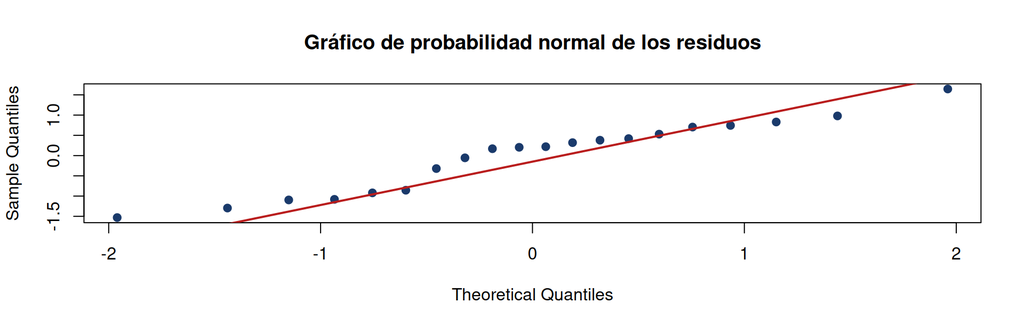

**Shapiro-Wilk:** $W=0.947$, valor-p$=0.319$. **Bartlett:** $K^2=1.73$, gl$=3$, valor-p$=0.630$.

Ambos supuestos se cumplen razonablemente: no hay evidencia para rechazar normalidad ni homogeneidad de varianzas.

## Gráfico de interacción tratamiento por bloque

El modelo aditivo del RCBD asume que el efecto del tratamiento es **el mismo** en todos los bloques (no hay interacción). Esto se verifica gráficamente con un gráfico de perfiles.

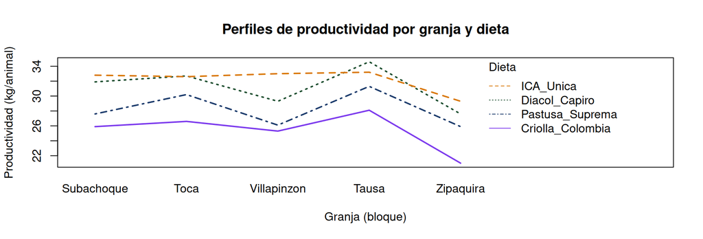

Las líneas son aproximadamente paralelas: no se observa un cruce sistemático, lo cual respalda el supuesto de aditividad. La **prueba de Tukey para no aditividad** permite formalizar esta verificación, contrastando $H_0:$ no hay interacción tratamiento-bloque.

## Otros aspectos del RCBD: eficiencia relativa del bloqueo

Una pregunta natural es: ¿valió la pena bloquear? La **eficiencia relativa** (ER) compara la precisión del RCBD con la de un DCA hipotético que hubiera ignorado el bloqueo.

Eficiencia relativa del bloqueo

$$ER = \frac{CM_{Bloq}(b-1) + b(a-1)\,CM_E}{(ab-1)\,CM_E}$$

$$ER=\frac{19.79(4)+5(3)(1.19)}{19(1.19)}=\frac{79.16+17.85}{22.61}\approx4.29$$

$ER\approx4.29$ significa que el RCBD es aproximadamente **4.3 veces más eficiente** que el DCA: hubiera sido necesario usar más de 4 veces el número de réplicas en un DCA para lograr la misma precisión.

## Observación faltante en el RCBD

En campo es común perder una observación (animal muerta, corral inundada). El procedimiento de Yates permite **estimar** el valor faltante para mantener el análisis balanceado.

Fórmula de Yates para un dato faltante

$$\hat y_{ij}=\frac{a\,B_j+b\,T_i-Y}{(a-1)(b-1)}$$

- $B_j$: total del bloque $j$ (sin el dato faltante).
- $T_i$: total del tratamiento $i$ (sin el dato faltante).
- $Y$: gran total (sin el dato faltante).

Suponga que se pierde el dato de ICA Única en Tausa (valor real $33.2$). Con $B_{Tausa}=94.0$, $T_{ICA}=127.7$, $Y=551.8$:
$$\hat y=\frac{4(94.0)+5(127.7)-551.8}{(4-1)(5-1)}=\frac{376+638.5-551.8}{12}\approx38.6$$

El valor estimado debe usarse con $1$ grado de libertad menos en el error, y el análisis posterior debe interpretarse con cautela: la estimación introduce algo de optimismo en la precisión.

## Estimación de parámetros y regresión general

El RCBD también puede expresarse como un modelo de regresión con variables indicadoras para tratamiento y para bloque, usando Pastusa Suprema y Subachoque como referencias.

| Coeficiente | Estimación | valor-p |
| --- | --- | --- |
| Intercepto (Pastusa, Subachoque) | 28.52 | $<0.001$ |
| Diacol Capiro | 3.00 | $<0.001$ |
| ICA Única | 3.96 | $<0.001$ |
| Criolla Colombia | -2.84 | 0.001 |
| Tausa | 2.25 | 0.013 |
| Zipaquirá | -3.60 | 0.001 |

El modelo de regresión explica el $93.9\%$ de la variabilidad ($R^2=0.939$), con $F=26.6$ (7, 12 gl), valor-p$=2.16\times10^{-6}$: el modelo global es altamente significativo, confirmando los resultados del ANOVA del RCBD.

## Comparaciones múltiples en el RCBD

Una vez rechazado $H_0$, las comparaciones de Tukey, Scheffé o Dunnett (vistas en la clase anterior) se aplican de la misma forma, usando $CM_E$ del RCBD con sus grados de libertad $(a-1)(b-1)$.

| Comparación | Diferencia | valor-p (Tukey) |
| --- | --- | --- |
| Dieta A - Dieta B | 3.00 | 0.012 |
| ICA Única - Dieta B | 3.96 | 0.002 |
| Dieta C - Dieta B | -2.84 | 0.025 |
| ICA Única - Dieta A | 0.96 | 0.498 |
| Dieta C - Dieta A | -5.84 | $<0.001$ |
| Dieta C - ICA Única | -6.80 | $<0.001$ |

ICA Única y Dieta A tienen el mayor productividad y no difieren significativamente entre sí; Dieta C presenta el menor productividad, significativamente inferior a las otras tres dietas.

## Errores comunes en el RCBD

Advertencia: errores frecuentes

- Bloquear por una variable que no afecta la respuesta: se pierden grados de libertad del error sin ganar precisión.
- Confundir bloque con tratamiento: el bloque nunca se asigna al azar a las unidades, ya existe (ej. la granja ya tiene su ubicación).
- Olvidar que cada bloque debe contener **todos** los tratamientos exactamente una vez (diseño “completo”).
- Ignorar la posible interacción tratamiento-bloque, que viola el supuesto de aditividad del modelo.

El Diseño de Cuadrado Latino

¿Qué hacer cuando existen DOS fuentes de variabilidad extraña que se desean controlar simultáneamente?

## Motivación: controlar dos fuentes de variabilidad

El RCBD controla una sola fuente de variación extraña (el bloque). Pero en muchos experimentos pecuarios existen **dos** fuentes simultáneas: por ejemplo, el tipo de dieta (por filas) y la época de manejo (por columnas).

El **Cuadrado Latino** permite controlar dos factores de bloqueo a la vez, usando un arreglo en filas y columnas donde cada tratamiento aparece exactamente una vez en cada fila y en cada columna.

Limitación importante: el número de filas, columnas y tratamientos debe ser **el mismo** ($a\times a$).

## Estructura y aleatorización del cuadrado latino

En un cuadrado latino de orden $a$, se construye una matriz $a\times a$ donde cada letra (tratamiento) aparece una sola vez en cada fila y en cada columna.

|  | Col 1 | Col 2 | Col 3 | Col 4 |
| --- | --- | --- | --- | --- |
| **Fila 1** | A | B | C | D |
| **Fila 2** | B | C | D | A |
| **Fila 3** | C | D | A | B |
| **Fila 4** | D | A | B | C |

La aleatorización consiste en permutar al azar las filas, luego las columnas y, opcionalmente, los símbolos de tratamiento de un cuadrado latino estándar.

## Modelo del cuadrado latino

Modelo del Cuadrado Latino

$$y_{ijk} = \mu + \alpha_i + \beta_j + \tau_k + \varepsilon_{ijk}$$

- $\alpha_i$: efecto de la fila $i$ (ej. lote), $i=1,\ldots,a$.
- $\beta_j$: efecto de la columna $j$ (ej. fecha de ingreso), $j=1,\ldots,a$.
- $\tau_k$: efecto del tratamiento $k$ (ej. dieta), $k=1,\ldots,a$.
- $\varepsilon_{ijk}\sim N(0,\sigma^2)$ independientes.
- Solo se observan $a^2$ combinaciones de las $a^3$ posibles: cada fila-columna recibe un único tratamiento.

## Ejemplo pecuario: dietas para aves en el Tolima

Un profesional en zootecnia del Espinal (Tolima) compara 4 dietas para aves: **Dieta A**, **Dieta B**, **Dieta C** y **Dieta D**. Controla por **lote** (filas, diferencias de calidad de la dieta) y por **fecha de ingreso** (columnas, diferencias climáticas estacionales).

|  | Fecha 1 | Fecha 2 | Fecha 3 | Fecha 4 |
| --- | --- | --- | --- | --- |
| **Lote 1** | F60 (6.80) | F67 (7.35) | F2000 (8.98) | Dieta D (6.50) |
| **Lote 2** | F67 (8.25) | F2000 (7.80) | Dieta D (7.23) | F60 (7.02) |
| **Lote 3** | F2000 (8.21) | Dieta D (5.86) | F60 (7.35) | F67 (8.21) |
| **Lote 4** | Dieta D (6.83) | F60 (7.16) | F67 (9.68) | F2000 (9.11) |

Productividad en kg/animal. Cada dieta aparece exactamente una vez en cada lote y en cada fecha.

## Medias del cuadrado latino: aves

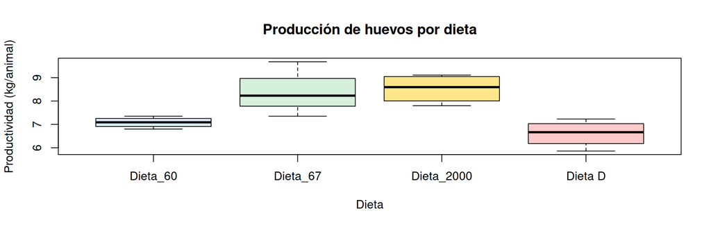

| Dieta | $\bar y_{..k}$ |
| --- | --- |
| Dieta A | 7.082 |
| Dieta B | 8.373 |
| Dieta C | 8.525 |
| Dieta D | 6.605 |

## Tabla ANOVA del cuadrado latino

El cuadrado latino descompone $SC_T$ en **cuatro** fuentes: dieta, lote, fecha y error, cada una con $a-1$ grados de libertad (excepto el error).

| Fuente | SC | gl | CM | F | valor-p |
| --- | --- | --- | --- | --- | --- |
| Dieta | 10.81 | 3 | 3.60 | 134.7 | $6.8\times10^{-6}$ |
| Lote (fila) | 1.68 | 3 | 0.56 | 20.9 | 0.0014 |
| Fecha (columna) | 3.30 | 3 | 1.10 | 41.1 | 0.0002 |
| Error | 0.16 | 6 | 0.027 |  |  |
| Total | 15.95 | 15 |  |  |  |

Los gl totales son $a^2-1=15$, distribuidos en $3(a-1)=9$ gl para las tres fuentes controladas y $(a-1)(a-2)=6$ gl para el error.

## Conclusión: aves en el Tolima

Criterio de decisión

$$F_{calc}=134.7 > F_{0.05,3,6}=4.76$$
$$\text{valor-p}=6.8\times10^{-6}<0.05$$
Se rechaza $H_0:\tau_1=\cdots=\tau_4=0$.

Conclusión

Existe evidencia estadística suficiente para afirmar que las dietas para aves difieren en productividad, controlando simultáneamente por lote y por fecha de ingreso.

Tanto el lote como la fecha de ingreso resultaron significativos, confirmando que ambas fuentes de variación extraña eran relevantes y que el diseño de cuadrado latino fue una elección apropiada.

## Errores comunes en el cuadrado latino

Advertencia: errores frecuentes

- Usar un cuadrado latino cuando filas, columnas y tratamientos no tienen el mismo número de niveles.
- Asumir que no existe interacción entre filas, columnas y tratamientos (el modelo es aditivo y no permite estimarla con un solo cuadrado).
- Con pocos tratamientos ($a\leq4$), el error tiene muy pocos grados de libertad: se recomienda repetir el cuadrado o usar $a\geq5$.
- Olvidar que cada combinación fila-columna solo puede tener un tratamiento (no es factorial completo).

El Diseño de Cuadrado Greco-Latino

¿Qué hacer cuando existen TRES fuentes de variabilidad extraña que se desean controlar al mismo tiempo?

## Motivación: tres fuentes de variabilidad extraña

En algunos ensayos de campo intervienen tres factores de bloqueo simultáneos: por ejemplo, el **lote**, la **época** de aplicación y el **operario** que aplica el tratamiento.

El **Cuadrado Greco-Latino** superpone dos cuadrados latinos ortogonales (uno con letras latinas, otro con letras griegas) sobre la misma matriz fila-columna, permitiendo controlar tres fuentes de variación con un solo experimento.

Limitación: los cuadrados latinos ortogonales de orden $a$ no existen para todo $a$ (por ejemplo, no existen para $a=6$); además se requiere que las cuatro fuentes (filas, columnas, latinas, griegas) tengan exactamente $a$ niveles.

## Estructura y modelo del cuadrado Greco-Latino

Modelo del Cuadrado Greco-Latino

$$y_{ijkl} = \mu + \alpha_i + \beta_j + \tau_k + \gamma_l + \varepsilon_{ijkl}$$

- $\alpha_i$: efecto de la fila $i$ (ej. lote).
- $\beta_j$: efecto de la columna $j$ (ej. época de aplicación).
- $\tau_k$: efecto del tratamiento latino $k$ (ej. dosis de suplemento).
- $\gamma_l$: efecto del tratamiento griego $l$ (ej. operario de aplicación).
- Solo $a^2$ de las $a^4$ combinaciones posibles se observan: cada nivel de fila, columna, latina y griega coincide exactamente una vez.

## Ejemplo conceptual: ensayo de suplementos

Una empresa de insumos pecuarios en el Valle del Cauca evalúa 4 dosis de un suplemento Mineral en avicultura de azúcar, controlando simultáneamente por **lote** (filas), **época** de aplicación (columnas) y **operario** encargado de aplicar el producto (letras griegas).

[output not shown]

Con solo $a=4$ niveles, los grados de libertad del error son $(a-1)(a-3)=3$, muy escasos: en la práctica se recomienda repetir el cuadrado o usar $a\geq5$.

Diseños de Bloques Incompletos Balanceados (BIBD)

¿Qué hacer cuando el bloque no tiene capacidad para recibir todos los tratamientos?

## Motivación: bloques de capacidad limitada

En ocasiones el tamaño del bloque es menor que el número de tratamientos: un instalación tiene espacio para 3 macetas, pero se desean comparar 7 dietas; una máquina de beneficio de ganado procesa solo 3 lotes por turno.

Un **Diseño de Bloques Incompletos Balanceados** (BIBD) asigna solo un subconjunto de $k<a$ tratamientos a cada bloque, garantizando que cada **par** de tratamientos aparezca junto el mismo número de veces $\lambda$ en algún bloque (de ahí “balanceado”).

Parámetros: $a$ tratamientos, $b$ bloques, $k$ unidades por bloque, $r$ réplicas por tratamiento, $\lambda$ coincidencias por par. Se cumple: $ar=bk$ y $\lambda(a-1)=r(k-1)$.

## Análisis estadístico del BIBD

A diferencia del RCBD, en el BIBD la suma de cuadrados de tratamiento **cruda** está contaminada por el efecto de bloque, ya que los tratamientos no se reparten igual en todos los bloques. Por ello se calcula una **suma de cuadrados ajustada**.

Suma de cuadrados de tratamiento ajustada

$$SC_{Trat(ajust)}=\frac{k\sum_{i=1}^a Q_i^2}{\lambda a}
\qquad
Q_i=T_i-\frac{1}{k}\sum_{j\in i} B_j$$

- $T_i$: total del tratamiento $i$. $B_j$: total del bloque $j$ que contiene al tratamiento $i$.
- $Q_i$: total ajustado del tratamiento $i$, que remueve el efecto de los bloques en que participó.
- $SC_{Bloq}$ se calcula de la forma usual con los totales de bloque.

## Ejemplo pecuario: dietas para ganado en Huila

Cenizoo evalúa 7 dietas para ganado (V1 a V7) en un animal de beneficio con capacidad de solo $k=3$ lotes por turno de procesamiento (bloque). Se diseña un BIBD con $b=7$ bloques, $r=3$ réplicas por dieta y $\lambda=1$.

| Bloque (turno) | Var. 1 | Var. 2 | Var. 3 | Rend. (kg/animal) |
| --- | --- | --- | --- | --- |
| 1 | V1 | V3 | V7 | 86.7 / 81.1 / 80.0 |
| 2 | V6 | V4 | V1 | 87.4 / 95.3 / 88.5 |
| 3 | V2 | V7 | V6 | 89.1 / 84.2 / 88.3 |
| 4 | V5 | V4 | V7 | 78.8 / 91.0 / 82.8 |
| 5 | V2 | V3 | V4 | 95.6 / 85.9 / 95.4 |
| 6 | V5 | V1 | V2 | 81.5 / 86.1 / 87.5 |
| 7 | V6 | V3 | V5 | 84.5 / 70.5 / 71.4 |

Cada par de dietas coincide en exactamente $\lambda=1$ bloque; cada dieta se repite $r=3$ veces.

## Medias crudas y ajustadas: ganado

```
Parameters BIB
==============
Lambda     : 1
treatmeans : 7
Block size : 3
Blocks     : 7
Replication: 3

Efficiency factor 0.7777778

<<< Book >>>
```

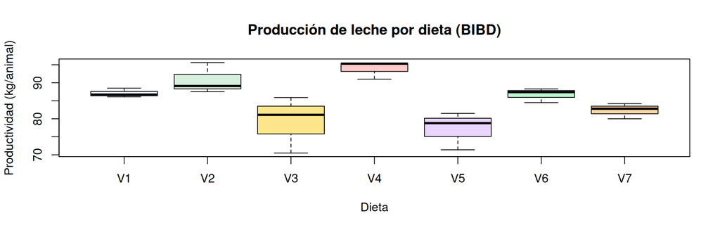

| Dieta | Media cruda | Media ajustada |
| --- | --- | --- |
| V1 | 87.10 | 86.71 |
| V2 | 90.73 | 88.60 |
| V3 | 79.17 | 79.80 |
| V4 | 93.90 | 91.66 |
| V5 | 77.23 | 79.74 |
| V6 | 86.73 | 88.37 |
| V7 | 82.33 | 82.31 |

## Tabla ANOVA del BIBD: ganado

La SC de tratamiento se ajusta por bloques incompletos; el orden correcto del modelo es bloque primero, tratamiento ajustado después.

| Fuente | SC | gl | CM | F | valor-p |
| --- | --- | --- | --- | --- | --- |
| Bloque | 552 | 6 | 91.9 | 15.40 | 0.0005 |
| Dieta (ajustada) | 310 | 6 | 51.6 | 8.65 | 0.0038 |
| Error | 48 | 8 | 6.0 |  |  |
| Total | 910 | 20 |  |  |  |

$F_{calc}=8.65 > F_{0.05,6,8}=3.58$, valor-p$=0.0038<0.05$: se rechaza $H_0$. Existe evidencia de que al menos una dieta de ganado difiere en productividad, una vez ajustado por el efecto de bloque (turno de beneficio).

## Estimación de parámetros por mínimos cuadrados en el BIBD

A diferencia del RCBD, en el BIBD las ecuaciones normales de mínimos cuadrados no se desacoplan limpiamente entre tratamientos y bloques, porque cada tratamiento no aparece en todos los bloques.

Estimador del efecto de tratamiento ajustado

$$\hat\tau_i=\frac{k\,Q_i}{\lambda a}$$

El estimador $\hat\tau_i$ corrige el efecto crudo del tratamiento $i$ restando la influencia de los bloques específicos en que participó. La media ajustada se obtiene como $\hat\mu+\hat\tau_i$, y son estas medias ajustadas (no las crudas) las que deben compararse mediante pruebas de comparación múltiple (ej. Tukey adaptado al BIBD).

En el ejemplo del ganado, V4 tiene la media ajustada más alta (91.66 kg/animal) y V5 la más baja (79.74 kg/animal); la comparación de Tukey adaptada agrupa a V4 como significativamente superior a V3 y V5.

## Recuperación de información interbloque

El análisis anterior (intrabloque) usa solo las comparaciones **dentro** de cada bloque. Sin embargo, si los efectos de bloque se tratan como **aleatorios**, es posible recuperar información adicional comparando los totales de bloque entre sí.

La **recuperación de información interbloque** combina ambas fuentes de información (intra e interbloque) mediante un promedio ponderado, lo que aumenta la precisión de las estimaciones de los efectos de tratamiento.

Se utiliza cuando se desea exprimir la máxima información posible del experimento, especialmente cuando hay pocos bloques. Su derivación completa requiere álgebra de mínimos cuadrados generalizados y excede el alcance de este curso introductorio.

En la práctica, software especializado (SAS PROC GLM, R con `lme4`) calcula automáticamente los estimadores combinados cuando se solicita el análisis con recuperación interbloque.

## Errores comunes en el BIBD

Advertencia: errores frecuentes

- Comparar las medias **crudas** de tratamiento en lugar de las medias **ajustadas**: las crudas están sesgadas por la composición de cada bloque.
- Diseñar un BIBD sin verificar que $\lambda(a-1)=r(k-1)$ sea un entero: si no se cumple, el balanceo no es posible con esos parámetros.
- Usar la fórmula de SC de tratamiento del RCBD (sin ajustar) cuando el diseño es incompleto.
- Olvidar que el orden de los términos en el modelo importa: la SC de bloque debe calcularse antes de ajustar el tratamiento.

## Resumen de los cuatro diseños

| Diseño | Fuentes controladas | Estructura | Ejemplo |
| --- | --- | --- | --- |
| RCBD | 1 (bloque) | Bloques completos | Cerdos, 5 granjas |
| Cuadrado Latino | 2 (fila y columna) | $a\times a$, 1 trat./celda | Aves, lote y fecha |
| Cuadrado Greco-Latino | 3 (fila, columna y griega) | 2 cuadrados ortogonales | Suplemento, operario |
| BIBD | 1 (bloque), capacidad limitada | Bloques incompletos balanceados | Ganado, 7 dietas en bloques de 3 |

Todos comparten la misma lógica: aislar fuentes de variación no relevantes para concentrar el análisis en el efecto del tratamiento de interés.

## Taller en Clase

## Instrucciones

Resuelva los siguientes ejercicios aplicando el diseño experimental indicado. Para cada uno: identifique el modelo, calcule la tabla ANOVA completa, aplique el criterio de decisión y redacte la conclusión en el contexto del problema.

Utilice $\alpha=0.05$ en todos los ejercicios, salvo que se indique lo contrario.

## Ejercicio 1

Una asociación de paneleros del Huila compara 3 dietas de avicultura panelera (**POJ 2878**, **PR 61632** y **CC 84-75**) en 4 trapiches (bloques), midiendo la producción de panela (kg/tonelada de avicultura).

| Trapiche | POJ 2878 | PR 61632 | CC 84-75 |
| --- | --- | --- | --- |
| 1 | 112 | 118 | 121 |
| 2 | 108 | 115 | 119 |
| 3 | 115 | 120 | 124 |
| 4 | 110 | 117 | 122 |

**Utilice:** un diseño de bloques completos aleatorizados (RCBD). Construya la tabla ANOVA y concluya si las dietas difieren en producción de panela.

## Ejercicio 2

En una granja ganadera de Casanare se desea comparar 4 suplementos alimenticios para ganado de ceba, controlando por **potrero** (filas, calidad del pasto) y por **mes** de inicio del ensayo (columnas, condiciones climáticas).

|  | Mes 1 | Mes 2 | Mes 3 | Mes 4 |
| --- | --- | --- | --- | --- |
| **Potrero 1** | A (18.2) | B (19.5) | C (17.0) | D (20.1) |
| **Potrero 2** | B (19.0) | C (16.8) | D (20.4) | A (18.0) |
| **Potrero 3** | C (16.5) | D (19.8) | A (18.4) | B (19.2) |
| **Potrero 4** | D (20.0) | A (18.6) | B (19.7) | C (17.2) |

**Utilice:** un diseño de cuadrado latino. Los valores son ganancia de peso (kg/mes). Construya la tabla ANOVA de cuatro fuentes y concluya.

## Ejercicio 3

Un criadero de aves en Madrid (Cundinamarca) desea comparar 6 dietas de rosa de exportación. Cada instalación (bloque) tiene capacidad para solo 3 dietas simultáneamente, por restricciones de espacio y manejo sanitario.

1. Proponga los parámetros $a$, $k$, $b$, $r$ y $\lambda$ de un BIBD adecuado para esta situación, verificando que $\lambda(a-1)=r(k-1)$ sea entero.
2. Explique por qué no sería válido comparar directamente las medias crudas de cada dieta sin ajustar por bloque.

**Utilice:** los conceptos de diseño de bloques incompletos balanceados (BIBD) y de suma de cuadrados de tratamiento ajustada.

## Ejercicio 4

En un ensayo de suplementación proteico en lotes de ternero Hass en Antioquia, se aplicó un RCBD con 5 tratamientos (incluyendo un control) en 4 granjas (bloques). Durante la producción, se perdió por completo el dato de la corral del **Tratamiento 3** en la **Granja 2** debido a una estres_termico localizada.

Los totales disponibles son: total del Tratamiento 3 (sin el dato faltante) $T_3=148$ kg; total de la Granja 2 (sin el dato faltante) $B_2=210$ kg; gran total (sin el dato faltante) $Y=1340$ kg.

**Utilice:** la fórmula de Yates para estimar el dato faltante, y discuta qué ajuste debe hacerse a los grados de libertad del error en el ANOVA posterior.

## Ejercicio 5

**Utilice:** la fórmula de eficiencia relativa $ER=\dfrac{CM_{Bloq}(b-1)+b(a-1)CM_E}{(ab-1)CM_E}$.